# **Project Fundamentals of AIML: Cardio Good Fitness Data Analysis**

**Marks: 40**

Author: Oscar Humberto Montejo Rodriguez

## **Context**

Cardio Good Fitness is a leading manufacturer of high-quality treadmills. The company offers three main products: the TM195, the TM498, and the TM798, which is their flagship product. With the rising demand for fitness in the market and an increasing number of competitors, Cardio Good Fitness wants to gain a better understanding of its existing customer profiles in order to develop more targeted marketing and product development strategies. They believe this will allow them to meet the needs and preferences of their customers, increase customer satisfaction, and drive revenue growth.

## **Objective**

In order to gain insights into its customer profiles, Cardio Good Fitness has collected demographic and product usage information for each of its customers. The dataset includes variables such as age, gender, income, and miles run on the treadmill for each of the three products.

Suppose you are hired as a Data Scientist in this company and the Data Science team has shared the data with you. The requirement is to analyze the data and identify patterns in product usage and the key characteristics of customers by conducting exploratory data analysis (EDA) to come up with customer profiles.

The goal is to answer key questions such as:

- What are the key characteristics of customers who purchase each product?
- How does product usage vary by each group?

## **Data Description**

The data is about customers of the treadmill product(s) of a retail store called Cardio Good Fitness. It contains the following variables-

- Product - The model no. of the treadmill
- Age - Age of the customer in no of years
- Gender - Gender of the customer
- Education - Education of the customer in no. of years
- Marital Status - Marital status of the customer
- Usage - Avg. number of times the customer wants to use the treadmill every week
- Fitness - Self rated fitness score of the customer (5 - very fit, 1 - very unfit)
- Income - Income of the customer
- Miles- Miles that a customer expects to run

### Let us start by importing the required libraries -

```python
# import libraries for data manipulation
import numpy as np
import pandas as pd

# import libraries for data visualization
import matplotlib.pyplot as plt
import seaborn as sns
```

### Understanding the structure of the data

```python
# read the data
df = pd.read_csv("CardioGoodFitness.csv")
```

```python
# copying data to another variable to avoid any changes to original data
cardio = df.copy()
```

```python
# returns the first 5 rows
cardio.head()
```

|  | Product | Age | Gender | Education | MaritalStatus | Usage | Fitness | Income | Miles |
| --- | --- | --- | --- | --- | --- | --- | --- | --- | --- |
| 0 | TM195 | 18 | Male | 14 | Single | 3 | 4 | 29562 | 112 |
| 1 | TM195 | 19 | Male | 15 | Single | 2 | 3 | 31836 | 75 |
| 2 | TM195 | 19 | Female | 14 | Partnered | 4 | 3 | 30699 | 66 |
| 3 | TM195 | 19 | Male | 12 | Single | 3 | 3 | 32973 | 85 |
| 4 | TM195 | 20 | Male | 13 | Partnered | 4 | 2 | 35247 | 47 |

#### Observations:

The DataFrame has 9 columns as mentioned in the Data Dictionary. Data in each row corresponds to the product purchased by a customer.

### **Question 1:** How many rows and columns are present in the data? [0.5 mark]

```python
# Getting the shape of the dataframe
[row, cols] = cardio.shape
print("rows:", row)
print("cols:", cols)
```

```
rows: 180
cols: 9
```

#### Observations:

The dataset 'CardioGoodFitness.csv' has 180 rows and 9 columns

### **Question 2:** What are the datatypes of the different columns in the dataset? (The info() function can be used) [0.5 mark]

```python
cardio.info()
```

```
<class 'pandas.core.frame.DataFrame'>
RangeIndex: 180 entries, 0 to 179
Data columns (total 9 columns):
 #   Column         Non-Null Count  Dtype
---  ------         --------------  -----
 0   Product        180 non-null    object
 1   Age            180 non-null    int64
 2   Gender         180 non-null    object
 3   Education      180 non-null    int64
 4   MaritalStatus  180 non-null    object
 5   Usage          180 non-null    int64
 6   Fitness        180 non-null    int64
 7   Income         180 non-null    int64
 8   Miles          180 non-null    int64
dtypes: int64(6), object(3)
memory usage: 12.8+ KB
```

#### Observations:

The next columns are string type columns:

- Product
- Gender
- MaritalStatus

And the others columns are numeric (integer) columns, which are:

- Age
- Education
- Usage
- Fitness
- Income
- Miles

### **Question 3:** Write a code to convert the data type of the object type variables to the 'categorical' type to reduce memory usage. [0.5 mark]

```python
cardio = df.copy()

# Get unique values
products = cardio["Product"].unique()
print("Products: ", products)
gender = cardio["Gender"].unique()
print("Gender: ", gender)
maritalStatus = cardio["MaritalStatus"].unique()
print("Marital Status: ", maritalStatus)

# Replace unique values with numbers
cardio["Product"] = cardio["Product"].replace(["TM195", "TM498", "TM798"], [0, 1, 2])
cardio["Gender"] = cardio["Gender"].replace(["Male", "Female"], [0, 1])
cardio["MaritalStatus"] = cardio["MaritalStatus"].replace(
    ["Single", "Partnered"], [0, 1]
)

# Print the results

print()
print("###### AFTER ######")
print()

products = cardio["Product"].unique()
print("Products: ", products)
gender = cardio["Gender"].unique()
print("Gender: ", gender)
maritalStatus = cardio["MaritalStatus"].unique()
print("Marital Status: ", maritalStatus)

cardio
```

```
Products:  ['TM195' 'TM498' 'TM798']
Gender:  ['Male' 'Female']
Marital Status:  ['Single' 'Partnered']

###### AFTER ######

Products:  [0 1 2]
Gender:  [0 1]
Marital Status:  [0 1]
```

|  | Product | Age | Gender | Education | MaritalStatus | Usage | Fitness | Income | Miles |
| --- | --- | --- | --- | --- | --- | --- | --- | --- | --- |
| 0 | 0 | 18 | 0 | 14 | 0 | 3 | 4 | 29562 | 112 |
| 1 | 0 | 19 | 0 | 15 | 0 | 2 | 3 | 31836 | 75 |
| 2 | 0 | 19 | 1 | 14 | 1 | 4 | 3 | 30699 | 66 |
| 3 | 0 | 19 | 0 | 12 | 0 | 3 | 3 | 32973 | 85 |
| 4 | 0 | 20 | 0 | 13 | 1 | 4 | 2 | 35247 | 47 |
| ... | ... | ... | ... | ... | ... | ... | ... | ... | ... |
| 175 | 2 | 40 | 0 | 21 | 0 | 6 | 5 | 83416 | 200 |
| 176 | 2 | 42 | 0 | 18 | 0 | 5 | 4 | 89641 | 200 |
| 177 | 2 | 45 | 0 | 16 | 0 | 5 | 5 | 90886 | 160 |
| 178 | 2 | 47 | 0 | 18 | 1 | 4 | 5 | 104581 | 120 |
| 179 | 2 | 48 | 0 | 18 | 1 | 4 | 5 | 95508 | 180 |

180 rows × 9 columns

### **Question 4:** Are there any missing values in the data? If yes, treat them using an appropriate method. [0.5 mark]

```python
cardio.isnull().sum()
```

```
Product          0
Age              0
Gender           0
Education        0
MaritalStatus    0
Usage            0
Fitness          0
Income           0
Miles            0
dtype: int64
```

#### Observations:

There are no missing values in the dataset

### **Question 5:** Check the statistical summary of the data. Which product type has had the highest number of sales? [1 marks]

```
[Text(0, 0, '80'), Text(0, 0, '60'), Text(0, 0, '40')]
```

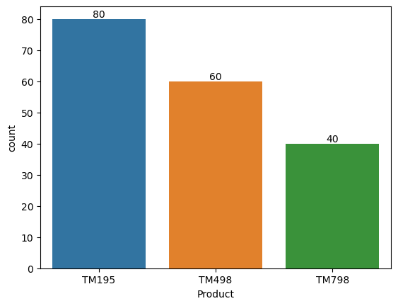

```python
cardio = df.copy()
ax = sns.countplot(data=cardio, x="Product")
ax.bar_label(ax.containers[0])
```

#### Observations:

The product TM195 has the highest number of sales with 80 sales on total

## **Exploratory Data Analysis (EDA)**

### **Question 6:** Explore all the variables and provide observations on their distributions. (Generally, histograms, boxplots, countplots, etc. are used for univariate exploration.) [6 marks]

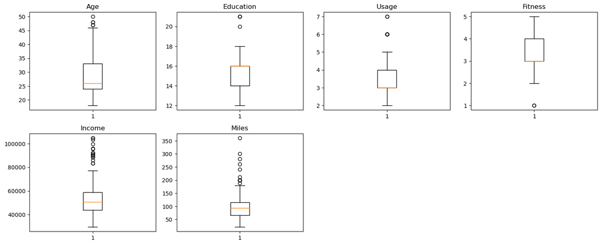

```python
numeric_columns = ["Age", "Education", "Usage", "Fitness", "Income", "Miles"]
plt.figure(figsize=(15, 12))

for i, variable in enumerate(numeric_columns):
    plt.subplot(4, 4, i + 1)
    plt.boxplot(cardio[variable], whis=1.5)
    plt.tight_layout()
    plt.title(variable)

plt.show()
```

```
[Text(0, 0, '104'), Text(0, 0, '76')]
```

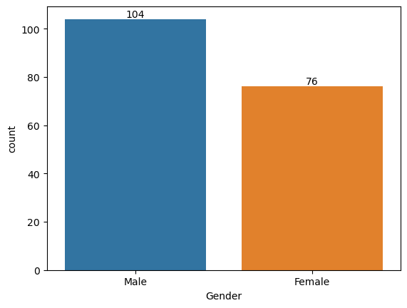

```python
ax = sns.countplot(data=cardio, x="Gender")
ax.bar_label(ax.containers[0])
```

**Creating bins for Age column**

- 18 - 30 years old - The property will be said to be in **`Young Adults`** location.
- 30 - 40 years old - The property will be said to be in **`30s`** location.
- 40 - 99 years old - The property will be said to be in **`+40s`** away location.

```python
cardio["age_bins"] = pd.cut(
    cardio["Age"],
    bins=[17, 30, 40, 99],
    labels=["Young Adults", "30s", "+40s"],
    right=False,
)
cardio
```

|  | Product | Age | Gender | Education | MaritalStatus | Usage | Fitness | Income | Miles | age_bins |
| --- | --- | --- | --- | --- | --- | --- | --- | --- | --- | --- |
| 0 | TM195 | 18 | Male | 14 | Single | 3 | 4 | 29562 | 112 | Young Adults |
| 1 | TM195 | 19 | Male | 15 | Single | 2 | 3 | 31836 | 75 | Young Adults |
| 2 | TM195 | 19 | Female | 14 | Partnered | 4 | 3 | 30699 | 66 | Young Adults |
| 3 | TM195 | 19 | Male | 12 | Single | 3 | 3 | 32973 | 85 | Young Adults |
| 4 | TM195 | 20 | Male | 13 | Partnered | 4 | 2 | 35247 | 47 | Young Adults |
| ... | ... | ... | ... | ... | ... | ... | ... | ... | ... | ... |
| 175 | TM798 | 40 | Male | 21 | Single | 6 | 5 | 83416 | 200 | +40s |
| 176 | TM798 | 42 | Male | 18 | Single | 5 | 4 | 89641 | 200 | +40s |
| 177 | TM798 | 45 | Male | 16 | Single | 5 | 5 | 90886 | 160 | +40s |
| 178 | TM798 | 47 | Male | 18 | Partnered | 4 | 5 | 104581 | 120 | +40s |
| 179 | TM798 | 48 | Male | 18 | Partnered | 4 | 5 | 95508 | 180 | +40s |

180 rows × 10 columns

## Plot the age categories

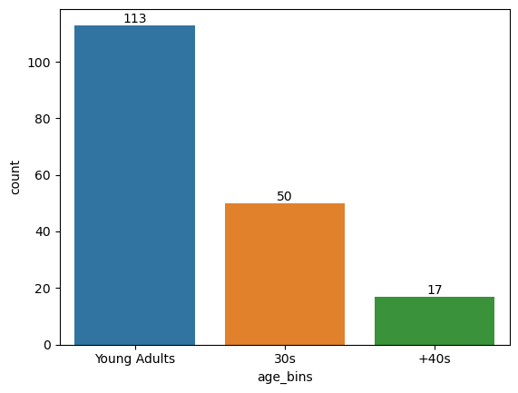

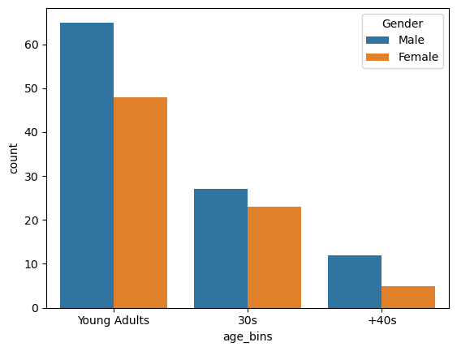

```python
ax = sns.countplot(data=cardio, x="age_bins")
ax.bar_label(ax.containers[0])
plt.show()

sns.countplot(data=cardio, x="age_bins", hue="Gender")
plt.show()
```

### Observations:

The users between 18 and 30's are the main users of the treadmill

### **Bivariate and Multivariate Analysis**

### **Question 7:** Perform bivariate and multivariate analysis to explore relationships between the important variables in the dataset. (It is a good idea to explore relations between numerical variables as well as relations between numerical and categorical variables) [12 marks]

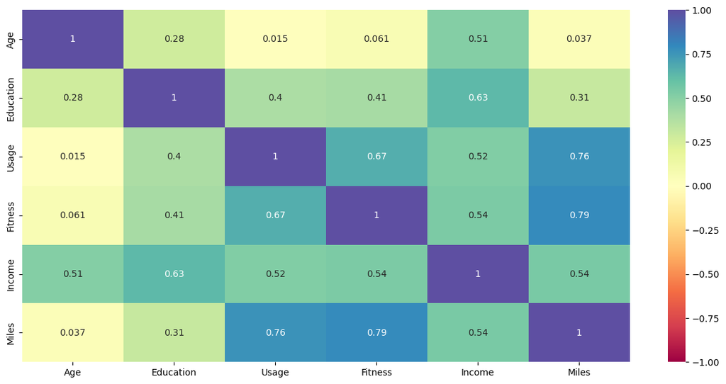

```python
# Check for correlation among numerical variables
num_var = ["Age", "Education", "Usage", "Fitness", "Income", "Miles"]

corr = cardio[num_var].corr()

# plot the heatmap

plt.figure(figsize=(15, 7))
sns.heatmap(corr, annot=True, vmin=-1, vmax=1, cmap="Spectral")
plt.show()
```

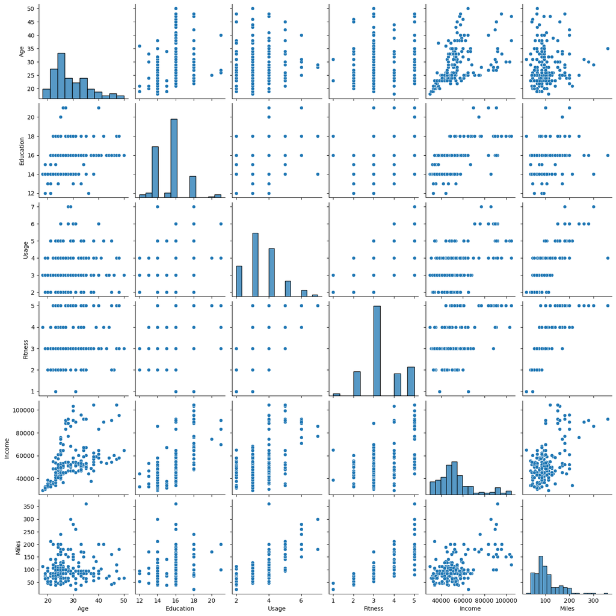

```python
sns.pairplot(data=cardio)
plt.show()
```

```
[Text(0, 0, '40'), Text(0, 0, '31'), Text(0, 0, '33')]
```

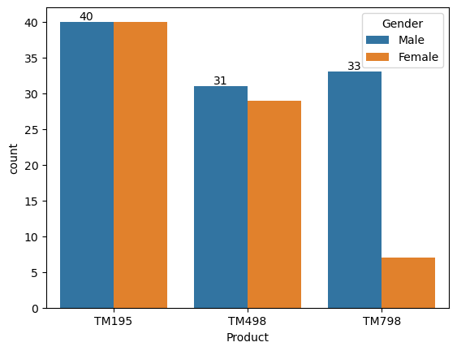

```python
ax = sns.countplot(data=cardio, x="Product", hue="Gender")
ax.bar_label(ax.containers[0])
```

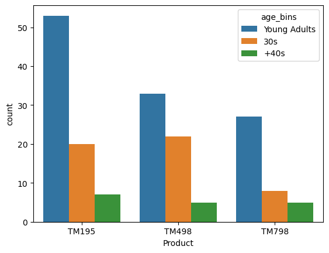

```python
ax = sns.countplot(data=cardio, x="Product", hue="age_bins")
```

### **Question 8:** Group the data for each product to build customer profiles and summarize the key characteristics of the customers based on the statistical summary. [3 marks]

```python
#split the dataframe on products
TM195 = cardio.loc[cardio["Product"] == "TM195"]
TM798 = cardio.loc[cardio["Product"] == "TM798"]
TM498 = cardio.loc[cardio["Product"] == "TM498"]

print(TM195.shape)
print(TM798.shape)
print(TM498.shape)

TM195
```

```
(80, 10)
(40, 10)
(60, 10)
```

|  | Product | Age | Gender | Education | MaritalStatus | Usage | Fitness | Income | Miles | age_bins |
| --- | --- | --- | --- | --- | --- | --- | --- | --- | --- | --- |
| 0 | TM195 | 18 | Male | 14 | Single | 3 | 4 | 29562 | 112 | Young Adults |
| 1 | TM195 | 19 | Male | 15 | Single | 2 | 3 | 31836 | 75 | Young Adults |
| 2 | TM195 | 19 | Female | 14 | Partnered | 4 | 3 | 30699 | 66 | Young Adults |
| 3 | TM195 | 19 | Male | 12 | Single | 3 | 3 | 32973 | 85 | Young Adults |
| 4 | TM195 | 20 | Male | 13 | Partnered | 4 | 2 | 35247 | 47 | Young Adults |
| ... | ... | ... | ... | ... | ... | ... | ... | ... | ... | ... |
| 75 | TM195 | 43 | Male | 16 | Partnered | 3 | 3 | 53439 | 66 | +40s |
| 76 | TM195 | 44 | Female | 16 | Single | 3 | 4 | 57987 | 75 | +40s |
| 77 | TM195 | 46 | Female | 16 | Partnered | 3 | 2 | 60261 | 47 | +40s |
| 78 | TM195 | 47 | Male | 16 | Partnered | 4 | 3 | 56850 | 94 | +40s |
| 79 | TM195 | 50 | Female | 16 | Partnered | 3 | 3 | 64809 | 66 | +40s |

80 rows × 10 columns

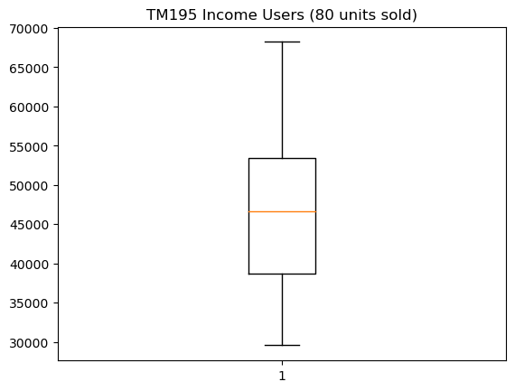

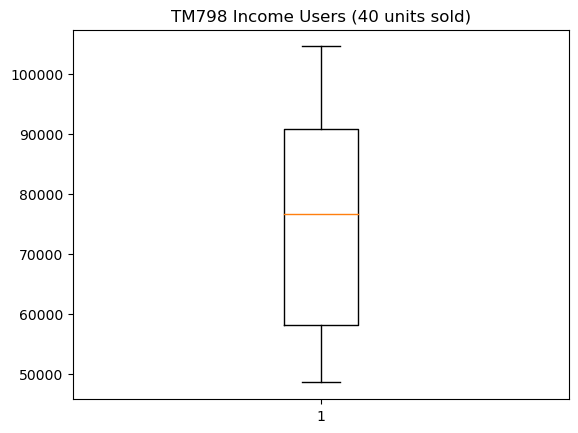

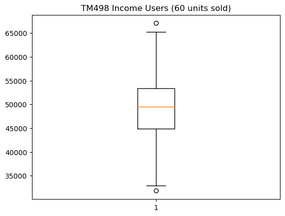

```python
#Plot some boxplot to see the user's incomes per Porduct
plt.boxplot(TM195["Income"])
plt.title("TM195 Income Users (80 units sold)")
plt.show()
plt.boxplot(TM798["Income"])
plt.title("TM798 Income Users (40 units sold)")
plt.show()
plt.boxplot(TM498["Income"])
plt.title("TM498 Income Users (60 units sold)")
plt.show()
```

```python
# Print the age categorie on TM195 treadmill
print("Total Young Adults: ", TM195.loc[TM195["age_bins"] == "Young Adults"].shape[0])
print("Total 30s: ", TM195.loc[TM195["age_bins"] == "30s"].shape[0])
print("Total +40s: ", TM195.loc[TM195["age_bins"] == "+40s"].shape[0])
```

```
Total Young Adults:  53
Total 30s:  20
Total +40s:  7
```

```python
print("User's income and age stats on TM195 treadmill:")
print()
TM195.describe()[['Income','Age']].T
```

```
User's income and age stats on TM195 treadmill:
```

|  | count | mean | std | min | 25% | 50% | 75% | max |
| --- | --- | --- | --- | --- | --- | --- | --- | --- |
| Income | 80.0 | 46418.025 | 9075.783190 | 29562.0 | 38658.0 | 46617.0 | 53439.0 | 68220.0 |
| Age | 80.0 | 28.550 | 7.221452 | 18.0 | 23.0 | 26.0 | 33.0 | 50.0 |

```python
print("User's income and age stats on TM798 treadmill:")
print()
TM798.describe()[['Income','Age']].T
```

[output not shown]

|  | count | mean | std | min | 25% | 50% | 75% | max |
| --- | --- | --- | --- | --- | --- | --- | --- | --- |
| Income | 40.0 | 75441.575 | 18505.836720 | 48556.0 | 58204.75 | 76568.5 | 90886.00 | 104581.0 |
| Age | 40.0 | 29.100 | 6.971738 | 22.0 | 24.75 | 27.0 | 30.25 | 48.0 |

```python
print("User's income and age stats on TM498 treadmill:")
print()
TM498.describe()[['Income','Age']].T
```

```
User's income and age stats on TM498 treadmill:
```

|  | count | mean | std | min | 25% | 50% | 75% | max |
| --- | --- | --- | --- | --- | --- | --- | --- | --- |
| Income | 60.0 | 48973.65 | 8653.989388 | 31836.0 | 44911.5 | 49459.5 | 53439.00 | 67083.0 |
| Age | 60.0 | 28.90 | 6.645248 | 19.0 | 24.0 | 26.0 | 33.25 | 48.0 |

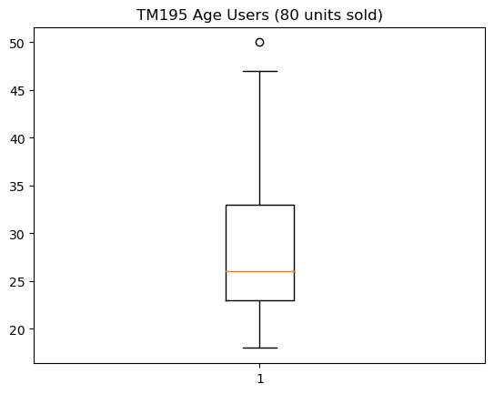

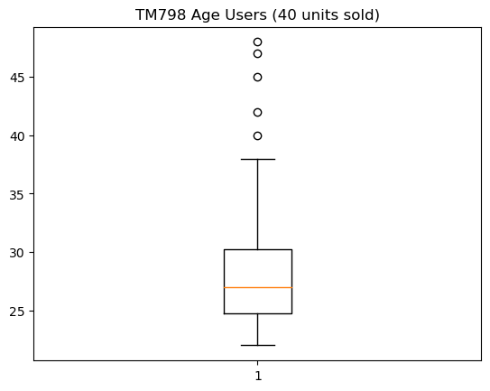

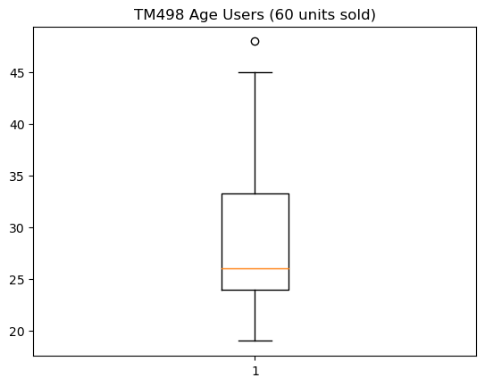

```python
plt.boxplot(TM195["Age"])
plt.title("TM195 Age Users (80 units sold)")
plt.show()
plt.boxplot(TM798["Age"])
plt.title("TM798 Age Users (40 units sold)")
plt.show()
plt.boxplot(TM498["Age"])
plt.title("TM498 Age Users (60 units sold)")
plt.show()
```

```python
print("User's income and age stats on TM498 treadmill and Young Adults:")
print()
TM195_Youngs = TM195.loc[TM195["age_bins"] == "Young Adults"]
TM195_Youngs.describe()[['Income','Age']].T
```

|  | count | mean | std | min | 25% | 50% | 75% | max |
| --- | --- | --- | --- | --- | --- | --- | --- | --- |
| Income | 53.0 | 42841.301887 | 7995.691704 | 29562.0 | 36384.0 | 42069.0 | 48891.0 | 68220.0 |
| Age | 53.0 | 24.226415 | 2.886584 | 18.0 | 22.0 | 24.0 | 26.0 | 29.0 |

```python
print("User's income and age stats on TM498 treadmill and 30s users:")
print()
TM195_30S = TM195.loc[TM195["age_bins"] == "30s"]
TM195_30S.describe()[['Income','Age']].T
```

|  | count | mean | std | min | 25% | 50% | 75% | max |
| --- | --- | --- | --- | --- | --- | --- | --- | --- |
| Income | 20.0 | 51676.65 | 6644.912746 | 37521.0 | 46617.0 | 52302.0 | 54860.25 | 67083.0 |
| Age | 20.0 | 34.45 | 2.910507 | 30.0 | 32.0 | 34.5 | 37.25 | 39.0 |

### **Question 9:** Summarize the key characteristics of each product based on the analysis performed. What recommendations would you like to share to help improve the business? [6 marks]

#### **Conclusion:**

- Our mains users are users between 18 and 30 years old
- The user's mean incomes are higher for TM798 treadmill users but and the same time it's the worst-selling treadmill
- The user's mean incomes are lower for TM195 treadmill users but and the same time it's the best-selling treadmill

#### **Recommendations:**

- Despite the incomes difference between young adult people and older people de mayority of the costumers are young adult people, we can focus the advertisements to this sector.
- The most popular product is the TM195 treadmill and 66.25% of the sellers have less than 30 years old, and the same time those users hadn't good incomes, may be we can create some price adjustments to fit with the users incomes.
- The TM798 treadmill users have the most higher income average, the advertisements of this product must be show that this is our premium product.
- May be it's a good idea create a new entry product (cheapper) focused on users between 18 and 30 years old that have incomes around 42841 dollars